# Creation of in-text tables

Laure Cougnaud

May 04, 2026

This vignette focuses on how to create in-text tables with the `inTextSummaryTable` package.

In this vignette we assume you have ready the `data.frame`(s) to create the tables. If you have doubts on the data format, please look the introductory vignette at the section “data format”.

We will use the example data available in the `clinUtils` package. Let’s load the packages and the data, and get started!

```r
    library(inTextSummaryTable)
    library(tools) # toTitleCase
```

```r
    library(clinUtils)

    # load example data
    data(dataADaMCDISCP01)

    dataAll <- dataADaMCDISCP01
    labelVars <- attr(dataAll, "labelVars")
```

The **`getSummaryStatisticsTable`** creates an in-text table of summary statistics for variable(s) of interest.

The *Demographic* data (`ADSL` dataset) is used as example for the summary statistics table.

```r
    dataSL <- dataAll$ADSL
```

# 1 Variable(s) to summarize

Variable(s) to summarize in the table are specified via the **`var` parameter**.

Different set of statistics are reported depending on the type of variable: Categorical variable or Continuous variable.

See the documentation in section *Base statistics* for more details on the statistics included by default for each type, via:

```r
? `inTextSummaryTable-stats`
```

## 1.1 Categorical variable

For a **discrete/categorical variable**, the in-text table can display the **counts/percentages of the number of subjects or records for each category** of the variable.

### 1.1.1 Counts of the entire dataset

If **no variable is specified** (via the `var` parameter), the counts are displayed for the **entire dataset**.

```r
    getSummaryStatisticsTable(data = dataSL)
```

| Statistic | StatisticValue (N=7) |
| --- | --- |
| statN | 7 |
| statm | 7 |
| statPercTotalN | 7 |
| statPercN | 100 |

Please note that this is equivalent of setting (`var = 'all'`).

### 1.1.2 Counts of categories

If a **variable is specified** (via the `var` parameter), the counts are displayed **for each category**.

```r
    getSummaryStatisticsTable(data = dataSL, var = "SEX")
```

| Variable group Statistic | StatisticValue (N=7) |
| --- | --- |
| F |  |
| statN | 5 |
| statm | 5 |
| statPercTotalN | 7 |
| statPercN | 71.43 |
| M |  |
| statN | 2 |
| statm | 2 |
| statPercTotalN | 7 |
| statPercN | 28.57 |

### 1.1.3 Sort categories

The categories of the variable are sorted alphabetically by default. To sort the categories in a specific order, the variable should be formatted as **`factor`**, whose ordered categories are included in its **`levels`**.

```r
    # specify manually the order of the categories
    dataSL$SEX <- factor(dataSL$SEX, levels = c("M", "F"))
    getSummaryStatisticsTable(data = dataSL, var = "SEX")
```

| Variable group Statistic | StatisticValue (N=7) |
| --- | --- |
| M |  |
| statN | 2 |
| statm | 2 |
| statPercTotalN | 7 |
| statPercN | 28.57 |
| F |  |
| statN | 5 |
| statm | 5 |
| statPercTotalN | 7 |
| statPercN | 71.43 |

```r
    # order categories based on a numeric variable
    dataSL$SEXN <- ifelse(dataSL$SEX == "M", 2, 1)
    dataSL$SEX <- reorder(dataSL$SEX, dataSL$SEXN)
    getSummaryStatisticsTable(data = dataSL, var = "SEX")
```

| Variable group Statistic | StatisticValue (N=7) |
| --- | --- |
| F |  |
| statN | 5 |
| statm | 5 |
| statPercTotalN | 7 |
| statPercN | 71.43 |
| M |  |
| statN | 2 |
| statm | 2 |
| statPercTotalN | 7 |
| statPercN | 28.57 |

### 1.1.4 Inclusion of categories not available in the data

By default, the table only includes the categories present in the input data, to ensure a compact table for CSR export.

```r
    dataSLExample <- dataSL

    # 'SEX' formatted as character with only male
    dataSLExample$SEX <- "M" # only male
    getSummaryStatisticsTable(data = dataSLExample, var = "SEX")
```

| Variable group Statistic | StatisticValue (N=7) |
| --- | --- |
| M |  |
| statN | 7 |
| statm | 7 |
| statPercTotalN | 7 |
| statPercN | 100 |

If extra categories should be represented in the table, the categorical variable should be **formatted as a factor**, whose **levels contain all categories** to be displayed in the table.

Furthermore, the parameter: `varInclude0` should be set to `TRUE` or to the specific variable (in case multiple variables are specified) to indicate that categories with 0 counts should be included.

```r
    # 'SEX' formatted as factor, to include also female in the table
    # (even if not available in the data)
    dataSLExample$SEX <- factor("M", levels = c("F", "M"))
    getSummaryStatisticsTable(data = dataSLExample, var = "SEX", varInclude0 = TRUE)
```

| Variable group Statistic | StatisticValue (N=7) |
| --- | --- |
| F |  |
| statN | 0 |
| statm | 0 |
| statPercTotalN | 7 |
| statPercN | 0 |
| M |  |
| statN | 7 |
| statm | 7 |
| statPercTotalN | 7 |
| statPercN | 100 |

```r
    # or:
    getSummaryStatisticsTable(data = dataSLExample, var = "SEX", varInclude0 = "SEX")
```

| Variable group Statistic | StatisticValue (N=7) |
| --- | --- |
| F |  |
| statN | 0 |
| statm | 0 |
| statPercTotalN | 7 |
| statPercN | 0 |
| M |  |
| statN | 7 |
| statm | 7 |
| statPercTotalN | 7 |
| statPercN | 100 |

### 1.1.5 Count table for ‘flag’-variables

A specific type of categorical variable is a **‘flag variable’**, which indicates if a record fulfills a specific criteria.

Such variable is typically formatted in the data as:

- ‘Y’ if the criteria is met for the specific record
- ‘N’ if the criteria is not fulfilled for the specific record
- ’’ if the criteria is missing for this record

The name of such variable typically ends with **‘FL’** in a CDISC-compliant *ADaM* or *SDTM* dataset.

For example, the subject-level dataset contains the following flag variables:

```r
    labelVars[grep("FL$", colnames(dataSL), value = TRUE)]
```

```
##                                    SAFFL                                    ITTFL                                    EFFFL                                  COMP8FL
##                 "Safety Population Flag"        "Intent-to-Treat Population Flag"               "Efficacy Population Flag"   "Completers of Week 8 Population Flag"
##                                 COMP16FL                                 COMP24FL                                 DISCONFL                                  DSRAEFL
##  "Completers of Week 16 Population Flag"  "Completers of Week 24 Population Flag" "Did the Subject Discontinue the Study?"                "Discontinued due to AE?"
##                                    DTHFL
##                          "Subject Died?"
```

```r
    # has the subject discontinued from the study?
    dataSL$DISCONFL
```

```
## [1] ""  ""  "Y" "Y" "Y" "Y" "Y"
```

If this variable is specified in `var`, the counts for each category is reported:

```r
    getSummaryStatisticsTable(
        data = dataSL,
        var = "SAFFL"
    )
```

| Variable group Statistic | StatisticValue (N=7) |
| --- | --- |
| Y |  |
| statN | 7 |
| statm | 7 |
| statPercTotalN | 7 |
| statPercN | 100 |

However, the interest is often to only reports the counts for the records fulfilling the criteria (records with ‘Y’). This is the case if the variable is specified via the `varFlag` parameter too.

```r
    getSummaryStatisticsTable(
        data = dataSL,
        var = "SAFFL",
        varFlag = "SAFFL"
    )
```

| Statistic | StatisticValue (N=7) |
| --- | --- |
| statN | 7 |
| statm | 7 |
| statPercTotalN | 7 |
| statPercN | 100 |

### 1.1.6 Inclusion of total across categories

To include the total counts across categories, the `varTotalInclude` parameter should be set to `TRUE` (or to the specific variable).

```r
    getSummaryStatisticsTable(
        data = dataSL,
        var = "SEX",
        varTotalInclude = TRUE
    )
```

| Variable group Statistic | StatisticValue (N=7) |
| --- | --- |
| Total |  |
| statN | 7 |
| statm | 7 |
| statPercTotalN | 7 |
| statPercN | 100 |
| F |  |
| statN | 5 |
| statm | 5 |
| statPercTotalN | 7 |
| statPercN | 71.43 |
| M |  |
| statN | 2 |
| statm | 2 |
| statPercTotalN | 7 |
| statPercN | 28.57 |

## 1.2 Continuous variable

For a **continuous variable**, the in-text table displays **standard distribution statistics** of the variable.

Please note that **missing records (NA) for the variable are filtered**, so the **count statistics** (number of subjects, records, percentage) are based **only on the non missing records**.

For a continuous variable, the presence of different values for the same subject (and across row/column variables) are checked and an appropriate error message is returned if multiple different values are available.

```r
    getSummaryStatisticsTable(data = dataSL, var = "AGE")
```

| Statistic | StatisticValue (N=7) |
| --- | --- |
| statN | 7 |
| statm | 7 |
| statMean | 74.29 |
| statSD | 9.827 |
| statSE | 3.714 |
| statMedian | 75 |
| statMin | 57 |
| statMax | 89 |
| statPercTotalN | 7 |
| statPercN | 100 |

## 1.3 Continuous and categorical variables in the table

The table can contain a mix of categorical and continuous variables.

```r
    getSummaryStatisticsTable(
        data = dataSL,
        var = c("AGE", "SEX")
    )
```

| Variable Variable group Statistic | StatisticValue (N=7) |
| --- | --- |
| AGE |  |
| statN | 7 |
| statm | 7 |
| statMean | 74.29 |
| statSD | 9.827 |
| statSE | 3.714 |
| statMedian | 75 |
| statMin | 57 |
| statMax | 89 |
| statPercTotalN | 7 |
| statPercN | 100 |
| SEX |  |
| F |  |
| statN | 5 |
| statm | 5 |
| statPercTotalN | 7 |
| statPercN | 71.43 |
| M |  |
| statN | 2 |
| statm | 2 |
| statPercTotalN | 7 |
| statPercN | 28.57 |

# 2 Statistics of interest

Statistics of interest and their format are specified via the **`stats` parameter**.

If an unique statistic expression is specified, the ‘Statistic’ column doesn’t appear in the table.  
In case multiple statistics are specified, these are included as separated row.

## 2.1 Standard statistic set

A standard set of statistics is specified via specific tags to be passed to the `stats` function.

The list of available statistics is mentioned in the section ‘*Formatted statistics*’ in:

```r
    ? `inTextSummaryTable-stats`
```

Please see below examples of commonly used statistics.

### 2.1.1 Categorical table

```r
    # count: n, '%' and m
    getSummaryStatisticsTable(
        data = dataSL,
        var = "SEX",
        stats = "count"
    )
```

| Variable group Statistic | StatisticValue (N=7) |
| --- | --- |
| F |  |
| n | 5 |
| % | 71.4 |
| m | 5 |
| M |  |
| n | 2 |
| % | 28.6 |
| m | 2 |

```r
    # n (%)
    getSummaryStatisticsTable(
        data = dataSL,
        var = "SEX",
        stats = "n (%)"
    )
```

| Variable group | n (%) (N=7) |
| --- | --- |
| F | 5 (71.4) |
| M | 2 (28.6) |

```r
    # n/N (%)
    getSummaryStatisticsTable(
        data = dataSL,
        var = "SEX",
        stats = "n/N (%)"
    )
```

| Variable group | n/N (%) (N=7) |
| --- | --- |
| F | 5/7 (71.4) |
| M | 2/7 (28.6) |

### 2.1.2 Continuous variable

```r
    ## continuous variable

    # all summary stats
    getSummaryStatisticsTable(
        data = dataSL,
        var = "AGE",
        stats = "summary"
    )
```

| Statistic | StatisticValue (N=7) |
| --- | --- |
| n | 7 |
| Mean | 74.3 |
| SD | 9.8 |
| SE | 3.71 |
| Median | 75.0 |
| Min | 57 |
| Max | 89 |
| % | 100 |
| m | 7 |

```r
    # median (range)
    getSummaryStatisticsTable(
        data = dataSL,
        var = "AGE",
        stats = "median (range)"
    )
```

| Median (range) (N=7) |
| --- |
| 75.0 (57,89) |

```r
    # median and (range) in a different line:
    getSummaryStatisticsTable(
        data = dataSL,
        var = "AGE",
        stats = "median\n(range)"
    )
```

| Median (range) (N=7) |
| --- |
| 75.0 (57,89) |

```r
    # mean (se)
    getSummaryStatisticsTable(
        data = dataSL,
        var = "AGE",
        stats = "mean (se)"
    )
```

| Mean (SE) (N=7) |
| --- |
| 74.3 (3.71) |

```r
    # mean (sd)
    getSummaryStatisticsTable(
        data = dataSL,
        var = "AGE",
        stats = "mean (sd)"
    )
```

| Mean (SD) (N=7) |
| --- |
| 74.3 (9.8) |

```r
    # mean and sd in separated rows
    getSummaryStatisticsTable(
        data = dataSL,
        var = "AGE",
        stats = c("Mean", "SD")
    )
```

| Statistic | StatisticValue (N=7) |
| --- | --- |
| Mean | 74.3 |
| SD | 9.8 |

## 2.2 Custom statistics formatting (Advanced)

To change the formatting of the statistics, the `stats` parameter should contain a language object (e.g. `expression` or `call`) of the default base set of statistics.

See the documentation in section ‘*Base statistics*’ for more details on the base statistics included by default, via:

```r
? `inTextSummaryTable-stats`
```

For example, the following count table is restricted to the number of subjects per categories:

```r
    getSummaryStatisticsTable(
        data = dataSL,
        var = c("RACE", "SEX"),
        stats = list(N = expression(statN))
    )
```

| Variable Variable group | N (N=7) |
| --- | --- |
| RACE |  |
| BLACK OR AFRICAN AMERICAN | 1 |
| WHITE | 6 |
| SEX |  |
| F | 5 |
| M | 2 |

The summary statistics table is restricted to the median and range:

```r
    getSummaryStatisticsTable(
        data = dataSL,
        var = c("AGE", "HEIGHTBL", "WEIGHTBL", "BMIBL"),
        varGeneralLab = "Parameter", statsGeneralLab = "",
        colVar = "TRT01P",
        stats = list(
            `median` = expression(statMedian),
            `(min, max)` = expression(paste0("(", statMin, ",", statMax, ")"))
        )
    )
```

| Parameter | Placebo (N=2) | Xanomeline High Dose (N=3) | Xanomeline Low Dose (N=2) |
| --- | --- | --- | --- |
| AGE |  |  |  |
| median | 82 | 69 | 78 |
| (min, max) | (75,89) | (57,74) | (76,80) |
| HEIGHTBL |  |  |  |
| median | 167.65 | 158.8 | 155.55 |
| (min, max) | (157.5,177.8) | (154.9,175.3) | (151.1,160) |
| WEIGHTBL |  |  |  |
| median | 59.65 | 66.7 | 54.45 |
| (min, max) | (47.2,72.1) | (51.7,87.1) | (45.4,63.5) |
| BMIBL |  |  |  |
| median | 20.9 | 27.8 | 22.75 |
| (min, max) | (19,22.8) | (20.5,28.3) | (17.7,27.8) |

Note that the ‘Standard statistics set’ is formatted internally via the `getStatsData` (and `getStats`) functions, which creates consistently a list of `language` objects.

```r
    # this count table:
    getSummaryStatisticsTable(
        data = dataSL,
        var = "SEX",
        stats = "count"
    )
```

| Variable group Statistic | StatisticValue (N=7) |
| --- | --- |
| F |  |
| n | 5 |
| % | 71.4 |
| m | 5 |
| M |  |
| n | 2 |
| % | 28.6 |
| m | 2 |

```r
    # ... is equivalent to:
    getSummaryStatisticsTable(
        data = dataSL,
        var = "SEX",
        stats = getStats(type = "count")
    )
```

| Variable group Statistic | StatisticValue (N=7) |
| --- | --- |
| F |  |
| n | 5 |
| % | 71.4 |
| m | 5 |
| M |  |
| n | 2 |
| % | 28.6 |
| m | 2 |

```r
    # this summary table...
    getSummaryStatisticsTable(
        data = dataSL,
        var = "AGE",
        stats = "mean (se)"
    )
```

| Mean (SE) (N=7) |
| --- |
| 74.3 (3.71) |

```r
    # ... is equivalent to:
    getSummaryStatisticsTable(
        data = dataSL,
        var = "AGE",
        stats = getStatsData(type = "mean (se)", var = "AGE", data = dataSL)[["AGE"]]
    )
```

| Mean (SE) (N=7) |
| --- |
| 74.3 (3.71) |

## 2.3 Statistics by variable/group

The statistics can also be provided for each variable separately, if `stats` is named by variable:

```r
    getSummaryStatisticsTable(
        data = dataSL,
        var = c("AGE", "RACE"),
        stats = list(
            AGE = getStats("median (range)"),
            RACE = getStats("n (%)")
        )
    )
```

| Variable Variable group Statistic | StatisticValue (N=7) |
| --- | --- |
| AGE Median (range) | 75 (57,89) |
| RACE |  |
| BLACK OR AFRICAN AMERICAN n (%) | 1 (14.3) |
| WHITE n (%) | 6 (85.7) |

## 2.4 Extra statistics

Extra statistics (not available in the default set of statistics) should be specified via the `statsExtra` parameter.

A set of extra utility functions to compute common extra statistics are also available in the package:

- coefficient of variation with the `cv` function
- geometric mean with the `geomMean` function
- geometric standard deviation with the `geomSD` function
- geometric coefficient of variation with the `geomCV` function

```r
    getSummaryStatisticsTable(
        data = dataSL,
        var = "HEIGHTBL",
        # specify extra stats to compute
        statsExtra = list(
            statCV = cv,
            statGeomMean = geomMean,
            statGeomSD = geomSD,
            statsGeomCV = geomCV
        )
    )
```

| Statistic | StatisticValue (N=7) |
| --- | --- |
| statN | 7 |
| statm | 7 |
| statMean | 162.2 |
| statSD | 10.25 |
| statSE | 3.873 |
| statMedian | 158.8 |
| statMin | 151.1 |
| statMax | 177.8 |
| statCV | 6.317 |
| statGeomMean | 161.9 |
| statGeomSD | 1.064 |
| statsGeomCV | 6.21 |
| statPercTotalN | 7 |
| statPercN | 100 |

Full customized statistics can also be provided. For example, if you would like to specify your own formula for the coefficient of variation:

```r
    # include the coefficient of variation via the 'statsExtra' parameter
    getSummaryStatisticsTable(
        data = dataSL,
        var = "HEIGHTBL",
        statsExtra = list(statCVPerc = function(x) sd(x)/mean(x)*100)
    )
```

| Statistic | StatisticValue (N=7) |
| --- | --- |
| statN | 7 |
| statm | 7 |
| statMean | 162.2 |
| statSD | 10.25 |
| statSE | 3.873 |
| statMedian | 158.8 |
| statMin | 151.1 |
| statMax | 177.8 |
| statCVPerc | 6.317 |
| statPercTotalN | 7 |
| statPercN | 100 |

These statistics are then available for customization via the `stats` parameter.

```r
    # format the statistics with the 'stats' parameter
    getSummaryStatisticsTable(
        data = dataSL,
        var = "HEIGHTBL",
        statsExtra = list(statCVPerc = function(x) sd(x)/mean(x)*100),
        stats = list(Mean = expression(statMean), 'CV%' = expression(statCVPerc))
    )
```

| Statistic | StatisticValue (N=7) |
| --- | --- |
| Mean | 162.2 |
| CV% | 6.317 |

## 2.5 Rounding strategy

Please note that all statistics are rounded by default in the package based on the **‘rounding up’ strategy for rounding off a 5**, which **differs from the default rounding strategy in R** (`round` function).

This was a deliberate choice to reproduce summarized statistics created with the SAS software.

Please find more explanations in the documentation of the `? roundHalfUp` and `? roundHalfUpTextFormat` functions.

## 2.6 Number of decimals

The detailed rules for the number of decimals for the statistics are described in the section *Statistics formatting* in:

```r
    ? `inTextSummaryTable-stats`
```

To specify fixed amounts of digits for the statistics to be displayed in the table, the statistics are formatted in the `stats` parameter.

### 2.6.1 Default number of decimals

#### 2.6.1.1 Categorical variable

The percentages are formatted by default as specified in the table below.

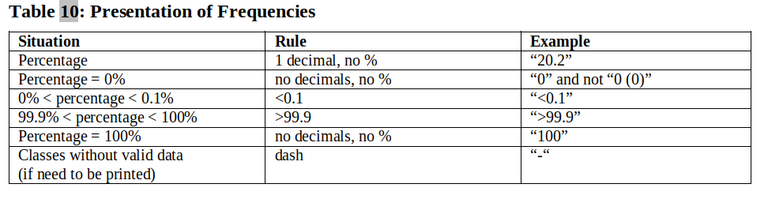

Standard Layout for Frequency Tabulations of Categorical Variables

By default, the counts for a categorical variables are formatted as specified above:

- the number of subjects is displayed with 0 digits (`nDecN` is set to 0)
- the frequency percentage is implemented in the `formatPercentage` function

```r
    # Internal rule for the number of decimals for the percentage
    formatPercentage(c(NA, 0, 100, 99.95, 0.012, 34.768))
```

```
## [1] "-"     "0"     "100"   ">99.9" "<0.1"  "34.8"
```

```r
    # Used by default in the 'getStats' function
    getStats(type = "count")
```

```
## $n
## roundHalfUpTextFormat(statN, 0)
##
## $`%`
## (function (x, nDec = 1)
## {
##     xRF <- ifelse(is.na(x), "-", ifelse(x == 0, "0", ifelse(x ==
##         100, "100", ifelse(x < 0.1, "<0.1", ifelse(x > 99.9,
##         ">99.9", roundHalfUpTextFormat(x, digits = nDec))))))
##     return(xRF)
## })(statPercN)
##
## $m
## roundHalfUpTextFormat(statm, 0)
```